# findPC - User Manual

Haotian Zhuang

Compiled: 03/20/2022

# Introduction

findPC is a software tool including six methods to automatically select the number of principal components to retain based on the standard deviations explained by each PC. A major advantage of findPC is that the only information required is a numeric vector of standard deviations explained by each PC.

# Installation

findPC software can be installed via Github. Users should have R installed on their computer before installing findPC. R can be downloaded here: http://www.r-project.org/. To install the latest version of findPC package via Github, run following commands in R:

```r
if (!require("devtools"))
install.packages("devtools")
devtools::install_github("haotian-zhuang/findPC")
library(findPC)
```

# findPC function

The synopsis of findPC is:  
`findPC(sdev,number = 30,method = 'perpendicular line',aggregate = NULL,figure = FALSE)`

The default is to return the number of PCs by Perpendicular line with 30 PCs. The following codes take the 50 PCs of the single-cell RNA-seq data in findPC package as an example.

```r
data(procdata)
sdev<-prcomp(t(procdata),scale. = T)$sdev[1:50]
head(sdev)
```

```
#> [1] 7.290341 5.522578 4.728735 3.425540 2.860214 2.735429
```

```r
findPC(sdev = sdev)
```

```
#>       Perpendicular line
#> 30PCs                  5
```

The argument ‘sdev’ should be sorted in decreasing order.

```r
findPC(sdev = -sdev)
```

```
#> Error in findPC(sdev = -sdev): 'sdev' should be sorted in decreasing order
```

## Number

The argument ‘number’ is a vector including number of PCs used in the following function.

```r
findPC(sdev = sdev,number = 51)
```

```
#> Error in findPC(sdev = sdev, number = 51): 'number' exceeds the available number of PCs
```

```r
findPC(sdev = sdev,number = c(24,36,48))
```

```
#>       Perpendicular line
#> 24PCs                  5
#> 36PCs                  5
#> 48PCs                  6
```

## Method

The argument ‘method’ specifies the six methods or returns the six results simultaneously.

```r
findPC(sdev = sdev,method = 'xxx')
```

```
#> Error in findPC(sdev = sdev, method = "xxx"): 'method' includes 'all','piecewise linear model',
#>     'first derivative','second derivative','preceding residual',
#>     'perpendicular line (default)','k-means clustering' options
```

```r
findPC(sdev = sdev,number = c(24,36,48),method = 'all')
```

```
#>       Piecewise linear model First derivative Second derivative
#> 24PCs                      5                6                 5
#> 36PCs                      5                6                 6
#> 48PCs                      5                6                 6
#>       Preceding residual Perpendicular line K-means clustering
#> 24PCs                  6                  5                  4
#> 36PCs                  6                  5                  4
#> 48PCs                 10                  6                  4
```

**Method 1: Piecewise linear model**

```r
findPC(sdev = sdev,number = c(24,36,48),method = 'piecewise linear model')
```

```
#>       Piecewise linear model
#> 24PCs                      5
#> 36PCs                      5
#> 48PCs                      5
```

**Method 2: First derivative**

```r
findPC(sdev = sdev,number = c(24,36,48),method = 'first derivative')
```

```
#>       First derivative
#> 24PCs                6
#> 36PCs                6
#> 48PCs                6
```

**Method 3: Second derivative**

```r
findPC(sdev = sdev,number = c(24,36,48),method = 'second derivative')
```

```
#>       Second derivative
#> 24PCs                 5
#> 36PCs                 6
#> 48PCs                 6
```

**Method 4: Preceding residual**

```r
findPC(sdev = sdev,number = c(24,36,48),method = 'preceding residual')
```

```
#>       Preceding residual
#> 24PCs                  6
#> 36PCs                  6
#> 48PCs                 10
```

**Method 5: Perpendicular line**

```r
findPC(sdev = sdev,number = c(24,36,48),method = 'perpendicular line')
```

```
#>       Perpendicular line
#> 24PCs                  5
#> 36PCs                  5
#> 48PCs                  6
```

**Method 6: K-means clustering**

```r
findPC(sdev = sdev,number = c(24,36,48),method = 'k-means clustering')
```

```
#>       K-means clustering
#> 24PCs                  4
#> 36PCs                  4
#> 48PCs                  4
```

## Aggregate

If users are also interested in the mean, median, or voting (median if all are different, otherwise mode) of the results, the argument ‘aggregate’ will support them.

```r
findPC(sdev = sdev,number = c(24,36,48),method = 'all',aggregate = 'mean')
```

```
#> mean
#>    6
```

```r
findPC(sdev = sdev,number = c(24,36,48),method = 'all',aggregate = 'median')
```

```
#> median
#>      6
```

```r
findPC(sdev = sdev,number = c(24,36,48),method = 'all',aggregate = 'voting')
```

```
#> mode
#>    6
```

## Figure

The last argument ‘figure’ provides the option to draw a heatmap showing the results.

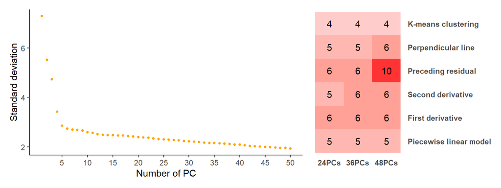

```
#>       Piecewise linear model First derivative Second derivative
#> 24PCs                      5                6                 5
#> 36PCs                      5                6                 6
#> 48PCs                      5                6                 6
#>       Preceding residual Perpendicular line K-means clustering
#> 24PCs                  6                  5                  4
#> 36PCs                  6                  5                  4
#> 48PCs                 10                  6                  4
```

```r
findPC(sdev = sdev,number = c(24,36,48),method = 'all',figure = T)
```